# Cartograflow

Filtering Matrix with concentration criterion for Thematic Flow Mapping

Cartograflow, 2020

2023-10-11

This vignette of `Cartograflow` is dedicated to the concentration analysis of an origin-destination matrix for flow mapping purposes.

## Main functions

**flowgini**

– `flowgini()` performs a Gini’s concentration analysis of the flow features, by computing *Gini coefficient* and plotting interactive *Lorenz curve*.

To be use before `flowanalysis()`

**flowanalysis** Flow filtering according to a concentration criterion

– `flowanalysis()` computes filters criterions based on:

- argument *critflow* is to filter the flows according to their significativity (% of total of flow information) ;
- argument *critlink* is to filter the flows according to their density (% of total features)

These arguments can be used as filter criterion in `flowmap()`.

## Useful additional function for a complete analysis

**Flowmap**

– `flowmap()` is to plot flows as segments or arrows, by acting on the following arguments:

- `filter` is to filter or not flow’s information or features
- `threshold` is used to set the filtering level of the flows when filter=“True”
- `taille` is the value of the width of the flow feature
- `a.head` is the arrow head parameter (in, out, in and out)
- `a.length` is the length of the edges of the arrow head (in inches)
- `a.angle` is the angle from the shaft of the arrow to the edge of the arrow head
- `a.col` is the arrow’s color
- `plota` is to add spatial features as map background to the flows’s plot
- `add` is to allow to overlay flow features on external spatial features background

## **1. Load datasets**

**Flow dataset**

```r
# Load Statistical information
data<-read.csv2("./data/MOBPRO_ETP.csv",
                header=TRUE,
                sep=";",
                stringsAsFactors=FALSE,
                encoding="UTF-8",
                dec=".",
                check.names=FALSE)
str(data)
```

```
## 'data.frame':    121 obs. of  4 variables:
##  $ i    : chr  "T1" "T1" "T1" "T1" ...
##  $ j    : chr  "T1" "T10" "T11" "T12" ...
##  $ Fij  : int  291058 8297 3889 17064 12163 32682 81129 16622 25317 1962 ...
##  $ count: int  351 43 13 77 52 55 134 63 53 14 ...
```

```r
# Variable typing
data$i<-as.character(data$i)
data$j<-as.character(data$j)
data$Fij<-as.numeric(data$Fij)
data$count<-as.numeric(data$count)

# Selecting useful variables
tabflow<-data%>%select(i,j,Fij)
```

**Geographical dataset**

```r
# Load a list of geo codes
ID_CODE<-read.csv2("./data/COD_GEO_EPT.csv",
                   header=TRUE,
                   sep=";",
                   stringsAsFactors=FALSE,
                   encoding="UTF-8",
                   dec=".",
                   check.names=FALSE)
#head(ID_CODE)

CODE<-ID_CODE%>% dplyr::select(COD_GEO_EPT)

colnames(CODE)<-c("CODGEO")
#head(CODE)

map<-st_read("./data/MGP_TER.shp")
```

## **2. Compute concentration criterion**

**2.1. Compute the concentration of flow values**

```r
# Computes Gini's coefficent
# head(tabflow,3)

tabgini<-flowgini(ODpts = tabflow,
                  origin="i",destination = "j",valflow = "Fij",
                  lorenz.plot = FALSE)
```

```
## Gini's coefficent =73.16 %
```

```r
# Interpretation ; The flows are quite concentrated on a few links, the Gini coefficent is equal to 73.16%

# Plot an interactive Lorenz curve

head(tabgini)
```

```
##       i  j    Fij link   flowcum     linkcum
## 1    T1 T1 291058    1 0.1819563 0.008264463
## 7    T1 T4  81129    1 0.2326745 0.016528926
## 13  T10 T1  73743    1 0.2787752 0.024793388
## 34  T12 T1  68625    1 0.3216765 0.033057851
## 61   T4 T1  66223    1 0.3630761 0.041322314
## 100  T8 T1  58770    1 0.3998165 0.049586777
```

```r
flowgini(ODpts = tabflow,
         origin="i",destination = "j",valflow = "Fij",
         lorenz.plot = TRUE)
```

[interactive chart not shown]

**2.2. Compute the “critflow” parameter (ex. significance)**

```r
# Compute critflow parameter

flowanalysis(tabgini,
             critflow = 0.8,
             result = "signif")
```

```
## [1] "threshold =  13442  ---  flows =  80 % ---  links =  23.14 %"
```

```r
# Interpretation : Flow values up to 13442 are the 80% largest one corresponding to 23,14 % of the total links' features.
```

**2.3. Flowmap filtered according to flows values significance** Using the ’critflow” to filter flows

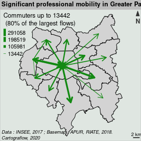

```r
# Graphic parameters
knitr::opts_chunk$set(fig.width=6, fig.height=6)
par(mar=c(0,0,1,0))
extent <- c(2800000, 1340000, 6400000, 4800000)
resolution<-150

# Overlay a spatial background
par(bg = "NA")
#plot(st_geometry(map), col = "#67786c")

# Add the corresponding background
plot(st_geometry(map), col = NA, border=NA, bg="#dfe6e1")
plot(st_geometry(map), col = "light grey", add=TRUE)

# For mapping flow up to 11238

flowmap(tab=tabflow,
        fij="Fij",origin.f = "i",destination.f = "j",
        bkg = map,code="EPT_NUM",nodes.X="X",nodes.Y = "Y",
        add=TRUE,
        filter=TRUE,
        threshold=13442,
        taille=15,
        a.head = 1,
        a.length = 0.11,
        a.angle = 30,
        a.col="#138913")


# Map Legend
legendPropLines(pos="topleft",
                title.txt="Commuters up to 13442\n (80% of the largest flows)",
                title.cex=0.8,
                cex=0.5,
                values.cex= 0.7,
                var=c(13442,max(tabflow$Fij)),
                lwd=15,
                frame = FALSE,
                col="#138913",
                values.rnd = 0
                )

#Map cosmetic

layoutLayer(title = "Significant professional mobility in Greater Paris",
           coltitle ="black",
           author = "Cartograflow, 2020",
           sources = "Data : INSEE, 2017 ; Basemap : APUR, RIATE, 2018.",
           scale = 2,
           tabtitle = FALSE,
           frame = TRUE,
           col = "grey",
            )
# north arrow
north("topright")
```

– **2.4. Flowmap filtered according to flow features’ density** Using the ’critlink” to filter flows

```r
flowanalysis(tabgini,
             critlink = 0.1,
             result = "density")
```

```
## [1] "threshold =  45772  ---  flows =  58.12 % ---  links =  10 %"
```

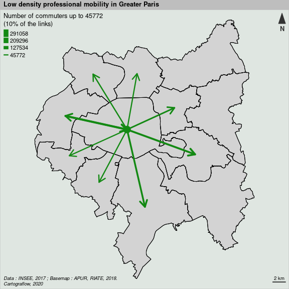

```r
# Interpretation : Flows up to 45772 are the 58.12% largest one corresponding to 10 % of the total links

# Graphic parameters
knitr::opts_chunk$set(fig.width=6, fig.height=6)
par(mar=c(0,0,1,0))
extent <- c(2800000, 1340000, 6400000, 4800000)
resolution<-150

# Overlay a spatial background
par(bg = "NA")

# Add the corresponding background
plot(st_geometry(map), col = NA, border=NA, bg="#dfe6e1")
plot(st_geometry(map), col = "light grey", add=TRUE)


# For mapping 10% of the total features as flows up to 45772 commuters

flowmap(tab=tabgini,
        fij="Fij",origin.f = "i",destination.f = "j",
        bkg = map,code="EPT_NUM",nodes.X="X",nodes.Y = "Y",
        add=TRUE,
        plota = TRUE,
        filter=TRUE,
        threshold=45772,
        taille=15,
        a.head = 1,
        a.length = 0.15,
        a.angle = 30,
        a.col="#138913")

# Map Legend
legendPropLines(pos="topleft",
                title.txt="Number of commuters up to 45772\n(10% of the links)",
                title.cex=0.8,
                cex=0.5,
                values.cex= 0.7,
                var=c(45772,max(tabgini$Fij)),
                lwd=15,
                frame = FALSE,
                col="#138913",
                values.rnd = 0
                )

#Map cosmetic
layoutLayer(title = "Low density professional mobility in Greater Paris",
           coltitle ="black",
           author = "Cartograflow, 2020",
           sources = "Data : INSEE, 2017 ; Basemap : APUR, RIATE, 2018.",
           scale = 2,
           tabtitle = FALSE,
           frame = TRUE,
           col = "grey"
            )

# north arrow
north("topright")
```

## Sample datasets

– *Statistical dataset* : - INSEE - Base flux de mobilité (2015) -URL : https://www.insee.fr/fr/statistiques/fichier/3566008/rp2015_mobpro_txt.zip

– *Geographical dataset* :

- municipalities : IGN, GEOFLA 2015 v2.1
- Greater Paris : APUR, UMS 2414 RIATE, 2018.

## See also

– cartograflow_general.html  
– cartograflow_distance.html  
– cartograflow_ordinal_distance.hmtl  
– cartograflow_concentration.hmtl

## Reference

– Bahoken Francoise (2016), Programmes pour R/Rtudio annexés, in : *Contribution à la cartographie d’une matrix de flux*, Thèse de doctorat, Université Paris 7, pp. 325-346. URL : https://halshs.archives-ouvertes.fr/tel-01273776, pp. 480-520.